# EHV-1 Genes’ transcript ratios

Balázs Kakuk

[output not shown]

# Project info

*Samples: dcDNA Seq*  
*pychopper: no*  
*mapping version: v6*  
*LoRTIA: yes (stranded only)*

*Filtering samples: C6_2h_3 & PC-12_8h_3*

## Only those reads were counted, where LoRTIA found *both* 5- and 3-prime adapters!

```
##         class_code      N
##             <char>  <int>
##  1:              =  20070
##  2:       5`-short 195142
##  3:        5`-long  70407
##  4:              o  41148
##  5:              x  84945
##  6:       3`-short  32130
##  7:              m   4882
##  8: Splice-variant  15076
##  9:              ~  13937
## 10:        3`-long   2502
## 11:              e   2966
## 12:              p   2694
## 13:              k   4666
## 14:              j   1496
## 15:              n    433
## 16:              i    164
## 17:              y    883
## 18:              c  44485
```

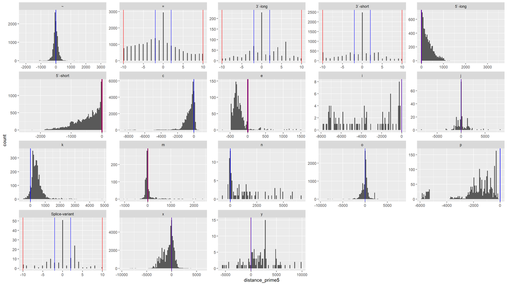

### Count only reads with distance <= 2 as equal (‘=’)

### CAGE significance

```
##    CAGE_significance     N
##               <char> <int>
## 1:              <NA>   235
## 2:               ***   262
## 3:                **    36
## 4:                 *    51
```

## Correct some genes in the annotation

DO NOT Filter second copies of genes, as in some cases there are transcripts from only one of the copies

```
##               TX_category     N
##                    <char> <int>
##  1:         Putative mRNA   137
##  2:      Non-coding-short     8
##  3:            Non-coding    26
##  4:    Monocistronic-Long    42
##  5:   Monocistronic-Short    38
##  6:   Multicistronic-Long     8
##  7:  Multicistronic-Short    10
##  8:                 CTO-L     1
##  9:               CTO-L-2     1
## 10:        Antisense-Long     2
## 11:       Non-coding-Long     1
## 12: Non-coding-intergenic     2
## 13:       Non-coding-long     1
```

```
##                TX_category width
##                     <char> <num>
##   1:            Non-coding   140
##   2:      Non-coding-short   154
##   3: Non-coding-intergenic   154
##   4:      Non-coding-short   163
##   5: Non-coding-intergenic   163
##  ---
## 273:    Monocistronic-Long  4640
## 274:    Monocistronic-Long  4713
## 275:  Multicistronic-Short  5126
## 276:   Multicistronic-Long  5191
## 277:   Multicistronic-Long  5482
```

### Add TX category

```
##  [1] "ORF11.5"         "ORF24.5"         "ORF39.5"         "ORF57.7"
##  [5] "ORF58.5"         "ORF64.1-L1"      "ORF71.5"         "NOIR-ORF65.1"
##  [9] "ORF18.5"         "ORF44.5"         "ORF44.6"         "ORF67.1"
## [13] "ORF30.5"         "ORF30.6"         "ORF35.5"         "ORF44.7"
## [17] "ORF14.5"         "ORF66.1"         "ncss65.1"        "nct65.1-Canonic"
## [21] "nct65.1-Long"    "ORF65.1-S"       "ORF65.1"         "ORF65.1-L1"
## [25] "ORF23.5"         "ORF24.6"         "ORF24.7"         "ORF24.8"
## [29] "ORF53.5"         "ORF57.5"         "ORF57.6"
```

### DISTANCE <= 2

### Include NAGATA results

```
##  [1] "ORF1-Putative mRNA-novTX_272"
##  [2] "ORF10-ORF11-ORF12-PC-Canonic"
##  [3] "ORF10-ORF11-PC-Canonic"
##  [4] "ORF14.5"
##  [5] "ORF14-Putative mRNA-novTX_339"
##  [6] "ORF31-Putative mRNA-novTX_81"
##  [7] "ORF42-Putative mRNA-novTX_153"
##  [8] "ORF43"
##  [9] "ORF43-ORF45-ORF46-PC-Canonic"
## [10] "ORF43-Monocistronic-Short-novTX_161"
## [11] "ORF54"
## [12] "ORF54-ORF55-ORF56-ORF57-CX-Canonic"
## [13] "ORF54-ORF55-ORF56-ORF57-ORF58-CX-Canonic"
## [14] "TR1063"
## [15] "TR1064"
```

[output cut: 46 more lines]

```
## [1] 8264
```

```
##           source     N
##           <fctr> <int>
## 1:   Torma_et_al   249
## 2: Tombacz_et_al   247
```

```
##            source           TX_category     N
##            <fctr>                <char> <int>
##  1:   Torma_et_al                  <NA>   221
##  2: Tombacz_et_al         Putative mRNA   129
##  3: Tombacz_et_al   Monocistronic-Short    36
##  4: Tombacz_et_al    Monocistronic-Long    29
##  5:   Torma_et_al         Putative mRNA    28
##  6: Tombacz_et_al            Non-coding    26
##  7: Tombacz_et_al      Non-coding-short     8
##  8: Tombacz_et_al  Multicistronic-Short     7
##  9: Tombacz_et_al   Multicistronic-Long     6
## 10: Tombacz_et_al Non-coding-intergenic     2
## 11: Tombacz_et_al       Non-coding-Long     1
## 12: Tombacz_et_al                 CTO-L     1
## 13: Tombacz_et_al               CTO-L-2     1
## 14: Tombacz_et_al       Non-coding-long     1
```

```
## [1] 8282
```

```
##           source     N
##           <fctr> <int>
## 1:   Torma_et_al   226
## 2: Tombacz_et_al   219
```

```
##            source          TX_category     N
##            <fctr>               <char> <int>
##  1:   Torma_et_al                 <NA>   200
##  2: Tombacz_et_al        Putative mRNA   119
##  3: Tombacz_et_al  Monocistronic-Short    36
##  4:   Torma_et_al        Putative mRNA    26
##  5: Tombacz_et_al           Non-coding    26
##  6: Tombacz_et_al   Monocistronic-Long    22
##  7: Tombacz_et_al     Non-coding-short     6
##  8: Tombacz_et_al Multicistronic-Short     5
##  9: Tombacz_et_al  Multicistronic-Long     3
## 10: Tombacz_et_al                CTO-L     1
## 11: Tombacz_et_al              CTO-L-2     1
```

### Merge NAGATA results

### Export gff

### Merge annotation and counts

```
##  [1] "NOIR-ORF65.1"
##  [2] "ORF13-ORF12-ORF11-ORF10-ORF9"
##  [3] "ORF21-ORF20-PC-Long-2"
##  [4] "ORF30-ORF31-ORF32-ORF33"
##  [5] "ORF40-ORF41-ORF42-CX-ORF43-ORF44"
##  [6] "ORF52-ORF51-ORF50-ORF49-ORF48-ORF44_47-ORF46-ORF45-CX-Canonic"
##  [7] "ORF53-ORF54-ORF55-ORF56-ORF57-ORF58"
##  [8] "ORF55-ORF56-PC-Long"
##  [9] "ORF6-ORF7-ORF8-ORF9-ORF10-ORF11"
## [10] "ORF65-ORF66-PC"
## [11] "ORF67-ORF68-ORF69-ORF70-ORF71"
## [12] "ORF67-ORF68-ORF69-ORF70-ORF71-ORF72-ORF73-ORF74"
## [13] "TR1146"
## [14] "TR173"
## [15] "TR4"
## [16] "TR8"
## [17] "as15"
## [18] "as23"
## [19] "as54"
```

### Include canonic annotation

### Include CAGE canonic-to-truncated reatios

```
##      TX_category     N
##           <char> <int>
## 1:       Canonic    53
## 2: Putative mRNA   167
```

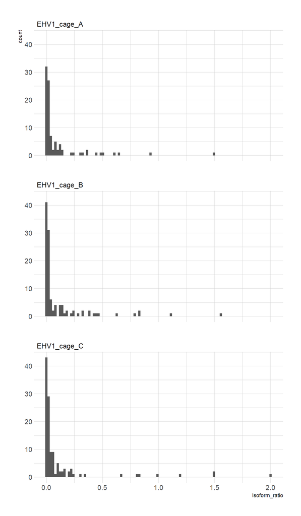

```
## character(0)
```

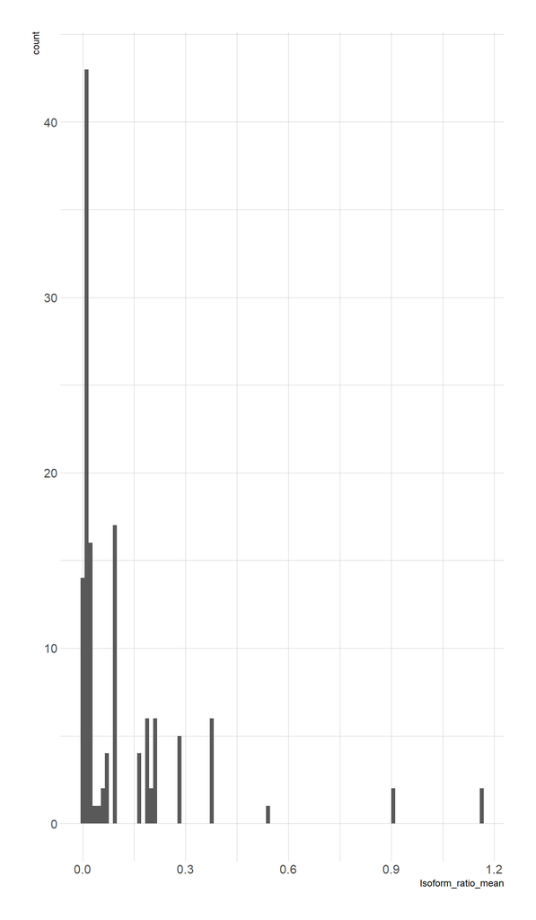

### Add CAGE Isoform ratio to tr.all.data

### Add categories from Torma

```
##            source           TX_category     N
##            <fctr>                <char> <int>
##  1: Tombacz_et_al       Non-coding-long     3
##  2:   Torma_et_al       Non-coding-Long     1
##  3: Tombacz_et_al      Non-coding-short     8
##  4:   Torma_et_al            Non-coding     5
##  5:   Torma_et_al             Antisense    19
##  6:   Torma_et_al        Multicistronic   123
##  7: Tombacz_et_al       Non-coding-Long     1
##  8:   Torma_et_al         Monocistronic    53
##  9:   Torma_et_al   Multicistronic-Long    69
## 10: Tombacz_et_al         Putative mRNA   137
## 11:   Torma_et_al  Multicistronic-Short    29
## 12:   Torma_et_al         Putative mRNA    30
## 13:   Torma_et_al      Monocistronic-AT     9
## 14:   Torma_et_al    Monocistronic-Long    66
## 15: Tombacz_et_al    Monocistronic-Long    42
## 16: Tombacz_et_al   Monocistronic-Short    38
## 17: Tombacz_et_al   Multicistronic-Long     8
## 18: Tombacz_et_al  Multicistronic-Short    10
## 19:   Torma_et_al   Monocistronic-Short     4
## 20: Tombacz_et_al            Non-coding    26
## 21: Tombacz_et_al        Antisense-Long     2
## 22: Tombacz_et_al Non-coding-intergenic     2
## 23:   Torma_et_al     Spliced-transcipt    75
## 24:   Torma_et_al        Antisense-long     9
## 25:   Torma_et_al       Antisense-short     1
## 26:   Torma_et_al       Non-coding-long     1
## 27:   Torma_et_al      Non-coding-short     1
##            source           TX_category     N
```

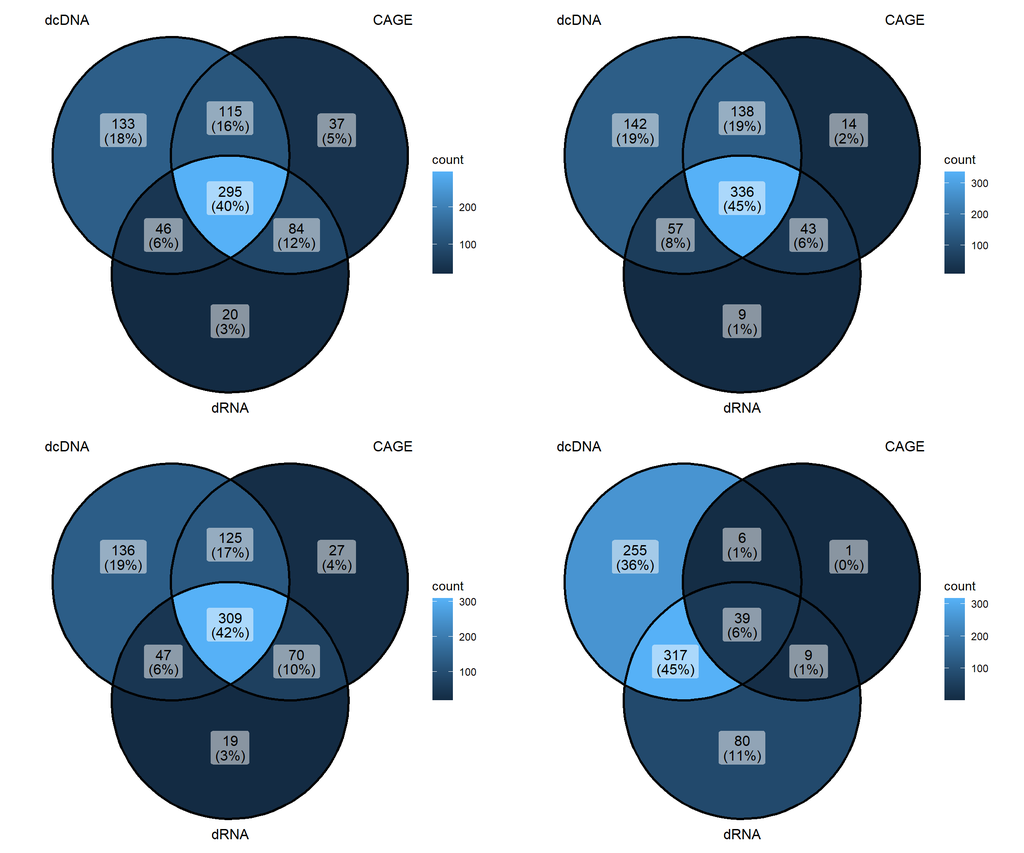

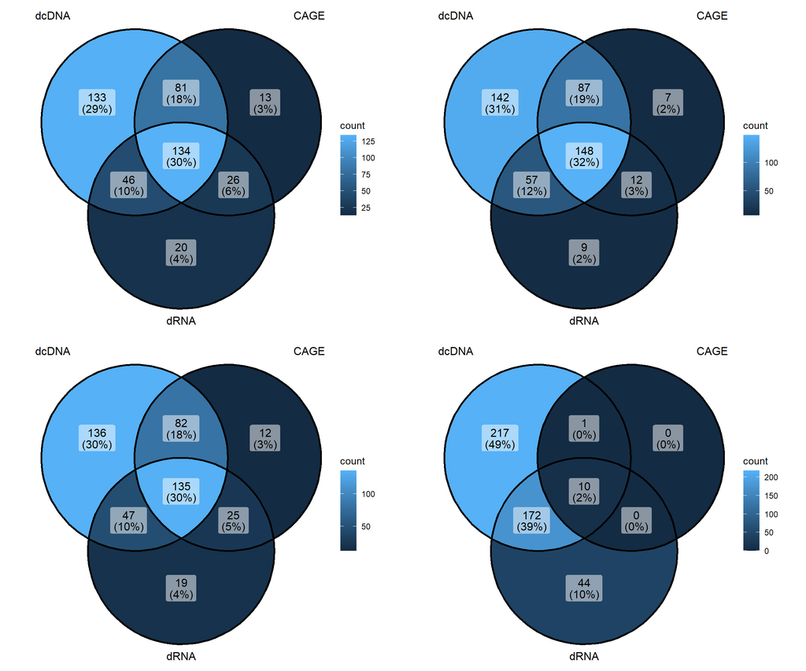

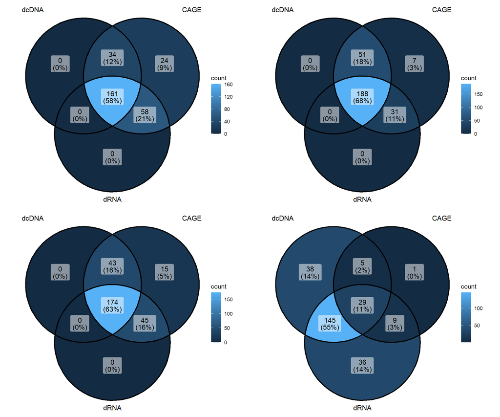

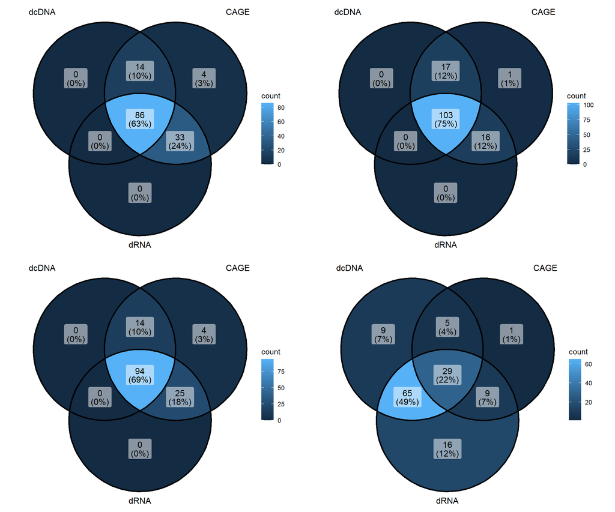

### Filter transcripts based on dRNA-NAGATA, CAGE-TSS-ratio and dcDNA-presence

### Export

## START MAIN WF

## Count normalization

# Counts based on iterative GFF-compare results

This was done as follows:

1. The reference transcripts were compared individually/iteratively to the reads.
2. The distances between the reads and each reference transcript hit were calculated.
3. For each read, the most similar reference transcript was assigned (lowest distance).
4. Additionally, these distances must had fulfill the following rules: *max prime5 distance <= 10*  
   *max prime3 distance <= 10*  
   *exon/intron junction difference <= 2*
5. Thus based on these, the read counts for each reference transcript were assessed.
6. The transcripts were then assigned to their parent genes (by Torma G) and their ratio (isoform ratio) was calculated as follows:  
   *isoform ratio = transcript isoform count / total gene count*
7. Those reads that could not be assigned to the reference transcripts were assigned to their parent genes, based on their 5-prime ends and independently to their parent gene cluster, based on their 3-prime ends.  
   So the reads are either:
- assigned to a reference transcript
- could not not be assigned to a ref TR, in which case they were:
  1. assigned to their parent gene based on their *5-prime* end overlapping with the gene’s *TSS*
  2. assigned to their parent gene-cluster based on their *3-prime* end overlapping with the cluster’s *TES*
  3. assigned to both

## 1. Kinetics of Reference Transcript Isoforms, according to their host gene

The reads were assigned to their parent gene based on their *5-prime* end overlapping with the gene’s *TSS*  
(but not necessarily with the gene cluster’s TES)

Merge annotation with RefClass

Exclude those ref transcripts that were not observed (or observed under the threshold) from the annotation as well

### Combine Transcript counts with annotation –>> Supp Table S2

# Plotting

### Annotation plotting function

### Isoform Ratio plotting function

### Merge IF ratio and annotation plots function

# START PLOTTING

## REVIEW

### Figure X - Anomalous transcripts

ORF23, ORF50, ORF67-ORF68, ORF64

### Figure 6 - DTU transcripts –>> OK

ORF11, ORF13, ORF14, ORF19, ORF40, ORF54

### Figure 4 - Spliced Transcripts –>> OK

ORF8, ORF9, ORF53, ORF38, ORF58, NOIR

### Supp Figure S9 - Spliced Transcripts 2 AND DTU 2 –>> OK

ORF47-44, ORF65

## For each gene

## Tests

### V1

### V2

## Archive

### Figure 3 V1 - Spliced Transcripts

ORF9, ORF38, ORF65, NOIR